# Consumption-Based Money Demand

Theoretical Properties and Transaction-Level Evidence

Jonathan J. Adams

Federal Reserve Bank of Kansas City

Mark Egan

Harvard Business School and NBER

November 17, 2026

The views expressed herein are those of the authors and do not necessarily represent the views of the Federal Reserve Bank of Kansas City or the Federal Reserve System.

## Motivation

- Literal money does not appear in the dominant New Keynesian approach; “monetary policy” is interest-rate policy.
- But households’ marginal asset is often money, and MPCs depend more on liquidity than on net wealth.
- Do monetary frictions matter for consumption and the macroeconomy in a modern high-velocity world?

## Baumol-Tobin and Friedman

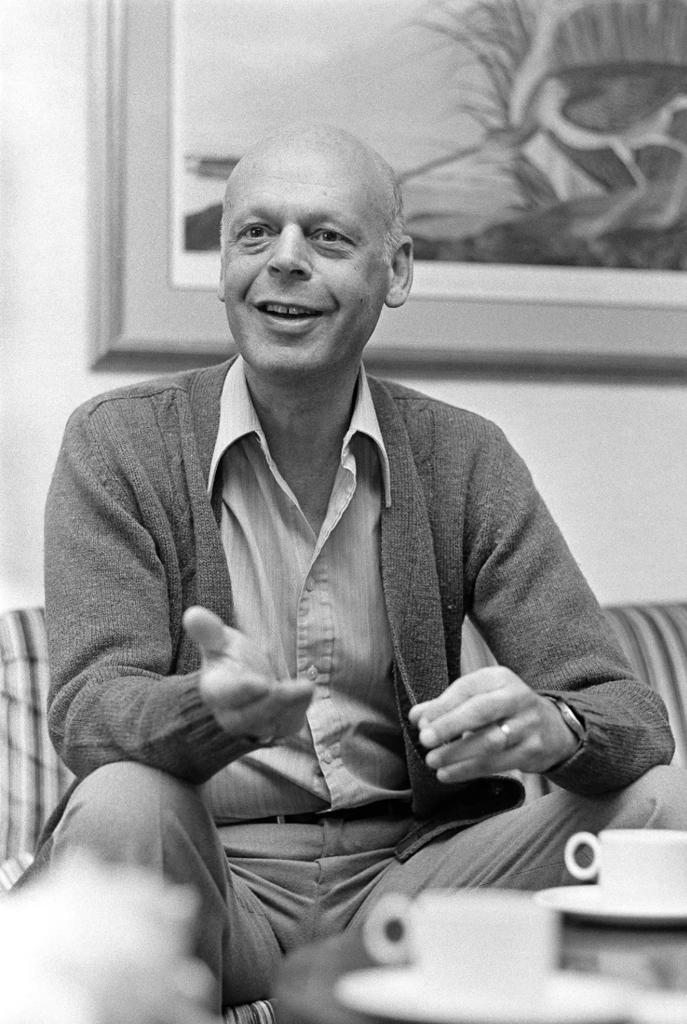

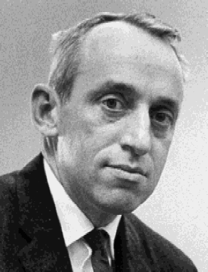

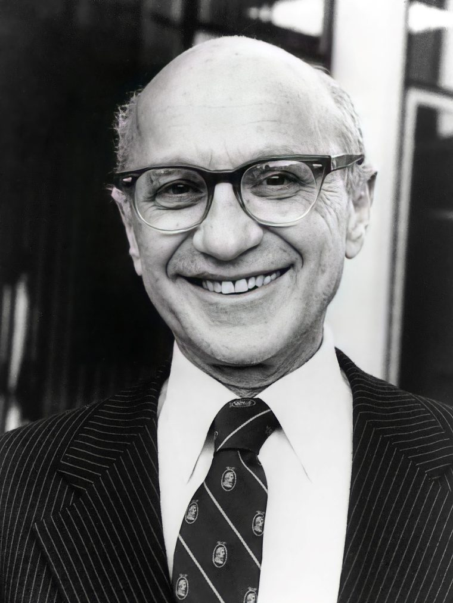

We add a standard consumption-saving decision to a model with fixed costs of adjusting money and assets.

## Main Results: Consumption

- Realistic Marginal Propensity to Consume (MPC)
  - Large MPCs across the wealth distribution (Kaplan et al., 2014; Kueng, 2018; Fagereng et al., 2021; Crawley and Kuchler, 2023; Bilbiie et al., 2025)
  - MPCs decline with liquidity (Souleles, 1999; Broda and Parker, 2014; Parker and Souleles, 2019; Jappelli and Pistaferri, 2020; Fagereng et al., 2021; Gelman, 2021; Aydin, 2022; Ganong et al., 2024)
  - iMPCs decay slowly (Johnson et al., 2006; Parker et al., 2013; Kueng, 2018; Fagereng et al., 2021; Aydin, 2022; Auclert et al., 2024)

## Main Results: Consumption (continued)

- Surprising properties:
  - **The cashless limit is not cashless**
    - MPCs distorted even as friction $\rightarrow 0$
    - Except: distortions disappear under Friedman rule
  - Risk is not necessary for (but amplifies) MPC distortions
  - iMPC slope depends on the inflation rate
  - MPCs aggregate exactly (consistent with HANKSSON evidence)
- Why?
  - Answer for all: *money + consumption smoothing*

## The Household Problem

- Households choose consumption and hold money and illiquid assets
- Consumption must be purchased with money; illiquid assets earn a higher return
- Portfolio adjustments require paying a Baumol-Tobin cost $\implies$ $(s,S)$ strategy and inaction region
- Income and expenditures can be risky

## Normalization (Perfect Foresight)

- Simplest example with all intuition: zero risk, illiquid income
- Between portfolio adjustments,
  $$\dot A=rA
  \qquad
  \dot M=-\pi M-C$$
- Normalize money $M$, consumption $C$ by illiquid assets $A$:
  $$m\equiv\frac{M}{A}
  \qquad
  c\equiv\frac{C}{A}$$
- Implies $m$ follows
  $$\boxed{\dot m=-im-c}\qquad
  i\equiv\pi+r$$

## Consumption Smoothing (Perf. Foresight)

- With log utility, homogeneity gives $V(M,A)=v(m)+w(A)$
- In the inaction region, HJB for the normalized value function is
  $$\rho v(m)=\max_c\left\{\log c+v'(m)(-im-c)\right\}$$
  $$\implies \boxed{\dot{c} = - (\rho + i) c}$$
- When $m=0$, the household pays $\varkappa$ and resets to optimal $m^*>0$.
- Intuition:
  - usually $\dot{c} = (r-\rho) c$
  - … but the **money is the marginal asset**, pays return $-i$

## Money Distorts the MPC

Consumption function $C(M,A)=c(m)A$ implies

$$C_M(M,A)=c'(m)
=\frac{\dot c}{\dot m}
=\frac{-(\rho+i)c(m)}{-im-c(m)}$$

- Distortion clear at the zero-balance boundary:

  $$\boxed{C_M(0,A)=c'(0)=\rho+i>\rho}$$
- $c'(m)>\rho$ for $m\in[0,\bar{m}]$ $\implies$ **MPC is elevated everywhere**
- $c''(m)<0$ $\implies$ **MPC is decreasing in liquidity**
- Why are MPCs distorted? **money is the marginal asset**

## MPC as a Function of Normalized Money

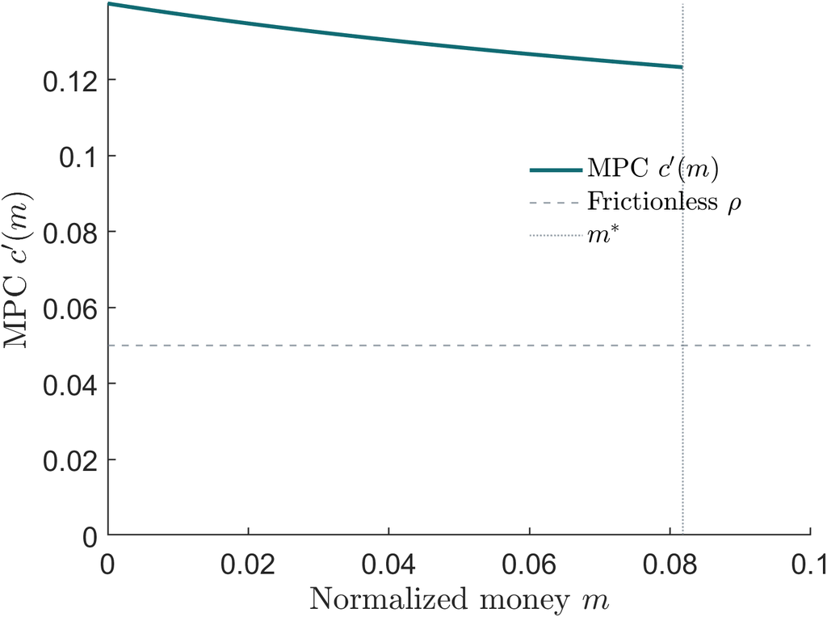

- Calibration: $\rho=r=.05$, $\pi=.04$; utility cost targets $m^*$ Calibration
- $c''(m)$ is small because $m$ is small:
  $$c'(m)=\frac{\rho+i}{\frac{im}{c(m)}+1}$$

## The Cashless Limit Is Not Cashless

- The MPC is anchored by $c'(0) = \rho + i$
- This is independent of the adjustment cost size!
- Reducing the friction moves $m^* \to 0$, and MPC is decreasing in $m$, so average MPC actually increases!

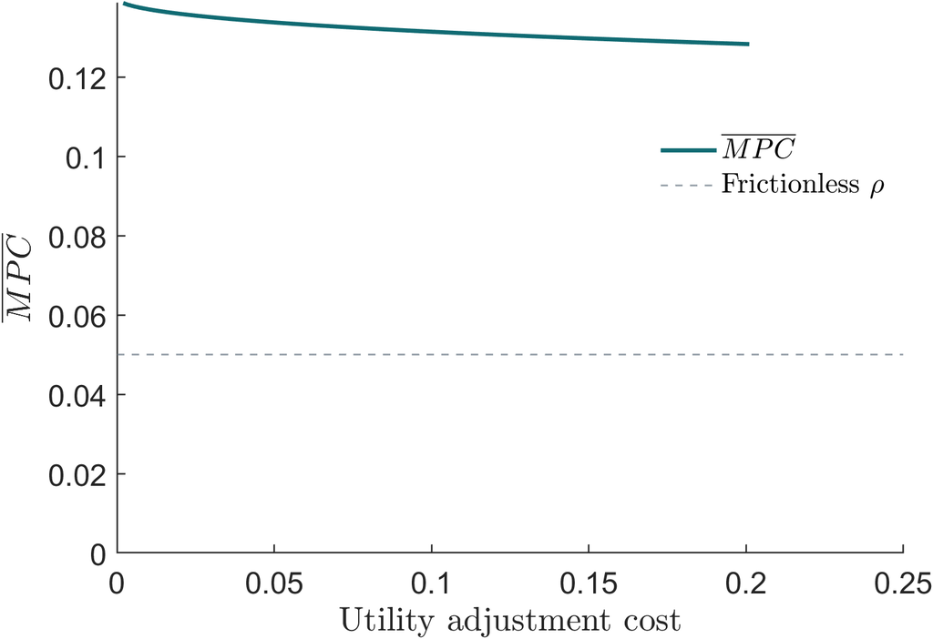

## The iMPC Slope

Before the next adjustment, the Euler equation implies
$$c_h=c(m)e^{-(\rho+i)h}$$

Because $A_h=A_0e^{rh}$ and $i=\pi+r$, level consumption satisfies
$$\frac{C_h}{A_0}
=e^{rh}c_h
=e^{-(\rho+\pi)h}c(m)$$

$$\text{iMPC is }\qquad \mathcal I(m,h)
\equiv\partial_m\frac{C_h}{A_0}
=e^{-(\rho+\pi)h}c'(m)$$

$$\implies \partial_h\log\mathcal I(m,h)=-(\rho+\pi)$$

## Introducing Risk

- The more general model introduces income and expenditure risk
- Income can be liquid, $\eta A$, or illiquid, $(r-\eta) A$
- Normalized money follows

  $$dm=\left(\eta-(\pi+r-\eta)m-c(m)\right)dt-\sigma dW^q$$
- For small risk, the main results go through (**Theorem 1**):
  - MPCs remain elevated
  - MPCs decline with liquidity
  - iMPCs decay slowly, depend on $\pi$
- Caveat: MPCs shrink sharply near the upper boundary $\bar m$

## Perfect Aggregation

- Let $G(M,A,t)$ be the joint density. After a common money transfer $\varepsilon$,

$$\begin{aligned}
\mathbf C(t;\varepsilon)
&=\iint C(M,A)G(M-\varepsilon,A,t)dM dA\\
\mathbf{MPC}(t)
&=\left.\partial_\varepsilon\mathbf C(t;\varepsilon)\right|_{\varepsilon=0}
=-\iint C(M,A)G_M(M,A,t)dM dA
\end{aligned}$$

- Integration by parts gives

$$\mathbf{MPC}(t)
=\underbrace{\iint C_MG\,dM dA}_{\text{average household MPC}}
-\underbrace{\int_0^\infty\left[CG\right]_{0}^{\bar M(A)}dA}_{\text{boundary term }=0}$$

- Absorbing boundary conditions $G(0,A,t)=G(\bar M(A),A,t)=0$
- Why do MPCs aggregate perfectly? *endogenous portfolio adjustment*

## The Aggregating Measure

- Shortcut for other aggregates: we do not need the full joint distribution
- The asset-weighted marginal of $\tilde G(m,A,t)$ is the *aggregating measure*:

$$\mathcal A(m,t)\equiv\int_0^\infty A\tilde G(m,A,t)dA$$

$$\mathbf A(t)=\int_0^{\bar m}\mathcal A(m,t)dm
\qquad
\mathbf M(t)=\int_0^{\bar m}m\mathcal A(m,t)dm
\qquad
\mathbf C(t)=\int_0^{\bar m}c(m)\mathcal A(m,t)dm$$

- Boundary flows: $\mathbf F_0^A(t)=\frac{\sigma^2}{2}\partial_m\mathcal A(0,t)$ and $\mathbf F_{\bar m}^A(t)=-\frac{\sigma^2}{2}\partial_m\mathcal A(\bar m,t)$
- Writing $\mu(m)$ for the drift of $m$, it follows a one-dimensional KFE (solve with Adams 2026):

$$\partial_t\mathcal A
=\frac{\sigma^2}{2}\partial_m^2\mathcal A
-\partial_m\!\left(\mu(m)\mathcal A\right)
+\alpha\mathcal A +\underbrace{\delta(m-m^*)
\left[\psi_0\mathbf F_0^A(t)+\psi_{\bar m}\mathbf F_{\bar m}^A(t)\right]}_{\text{asset-weighted resets}}$$

## Sluggish Money Demand

- No static money demand curve relates aggregate $M/P$ to $i$, $Y$, etc.
- Money demand is *sluggish*: $i$, $Y$, etc. only affect households that adjust
- E.g. a helicopter drop moves most households within the inaction region; only some adjust
- Extra balances spent gradually, affect future adjustment flows
- **Quantitative Question:** How sluggish is it?

## A Helicopter Drop

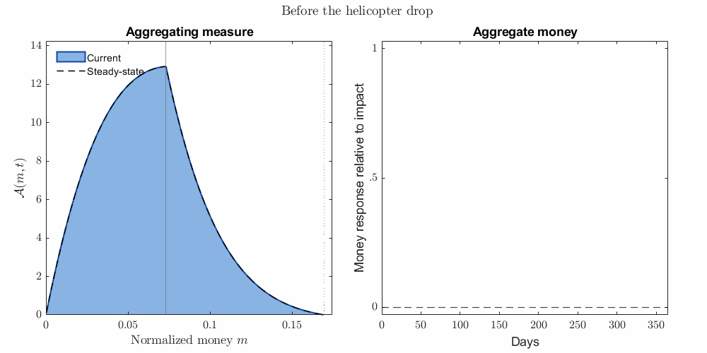

## A Functional Sufficient Statistic

- Steady-state adjustment statistics reveal the entire IRF to a monetary shock
- More general than our model (arbitrary consumption + hazard fns, etc.)
- Marginal effect on aggregate real balance depends on: (1.) average iMPC and (2.) net liquidation response $\mathbf L^{\varepsilon_m}(t)$
- Simplest with illiquid income ($\eta=0$):

$$\mathbf M^{\varepsilon_m}(t)
=e^{-\pi t}
-\underbrace{\int_0^t e^{-\pi(t-s)}\overline{\operatorname{iMPC}}(s)ds}_{\text{consumption response}}
+\underbrace{\int_0^t e^{-\pi(t-s)}\mathbf L^{\varepsilon_m}(s)ds}_{\text{net liquidation response}}$$

- Ingredients for $\mathbf L^{\varepsilon_m}(t)$: weighted conditional distributions of reset balances and adjustment sizes

Details

## Transaction-Level Data

Statistics

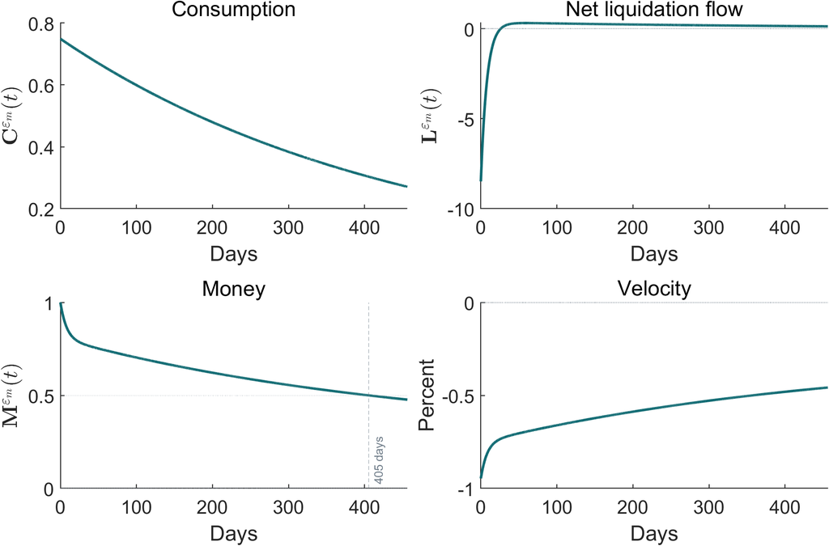

Fit iMPC to evidence from lottery windfalls (Fagereng et al 2021)

## Conclusion

- A standard Baumol-Tobin friction + endogenous consumption smoothing $\rightarrow$ realistic MPC distortions
- **The cashless limit is not cashless**: money matters, even in high velocity economies.
- Aggregate money demand is sluggish; we can determine how sluggish from transaction-level data.

## Thoughts for Future Work

Richmond Fed President Tom Barkin on the causes of the post-COVID inflation:

> “Some point to the dramatic increase in the money supply. Since the start of the pandemic, in the context of government deficits and asset purchases, M2 grew 40 percent.”

But…

> “In the last recovery, when M2 increased nearly 46 percent between 2010 and 2015, we saw five-year inflation fall from 2.2 percent to 1.4 percent. If money supply were the driving force today, we would need to understand why it wasn’t back then.”

Perhaps the key is not to look at M2, but specifically at household money:

- **2010Q1–2015Q1:** household money grew **4.4%** annually, while real GDP grew **2.4%**
- **2019Q4–2024Q4:** household money grew **7.5%** annually, while real GDP grew **2.4%**

## Baseline Calibration

Targets: $\mathbf M/\mathbf A=6.2\%$ and adjustment-size ratio $=1.331$.

Benchmark: $\mathbf M/\mathbf A=6.2\%$, adjustment-size ratio $=1.331$, money-response half-life $\approx60$ days.

| Parameter | Value |
| --- | --- |
| $\rho=r$ | 0.05 |
| $\pi$ | 0.04 |
| $i$ | 0.09 |
| $\sigma$ | 0.0571 |
| $\eta$ | 0.0089 |
| $\varkappa$ | 0.1084 |

| Model statistic | Value |
| --- | --- |
| $\mathbf M/\mathbf A$ | 0.062 |
| Size ratio (I/L) | 1.331 |
| Half-life (days) | 59.8 |
| Liquidations/year | 0.686 |
| Illiquidations/year | 0.023 |

I/L denotes illiquidation/liquidation.

Back

## Money and Adjustment Statistics

| Balances and timing | Data |
| --- | --- |
| Average balance | $14,715 |
| Balance $\operatorname{CV}^2$ | 7.61 |
| Adjustments/year | 8.01 |
| Liquidations/year | 4.60 |
| Illiquidations/year | 3.41 |
| Average duration (years) | 0.125 |

[output not shown]

Frequencies are per household per year. Amounts are in dollars; the second moment is in dollars squared.

Back

## Measuring the Next Adjustment

- Let $a$ be time since the last adjustment and $B_0$ the balance immediately afterward. Define

$$Z\equiv B_0e^{\alpha a}
\qquad
x\equiv\frac{M}{Z}$$

- Let $\tau$ be time to the next adjustment, $B_1$ the balance immediately afterward, and $\Delta M$ the signed adjustment

$$\begin{aligned}
\mathcal F_B(t\mid x)
&\equiv\mathbb E\left[\frac{B_1}{Z}\mathbf 1\{\tau\leq t\}\,\middle|\,x\right]\\
\mathcal F_J(t\mid x)
&\equiv\mathbb E\left[\frac{\Delta M}{Z}\mathbf 1\{\tau\leq t\}\,\middle|\,x\right]
\end{aligned}$$

- $\bar h_Z(x)$ is the steady-state distribution of relative balances, weighted by $Z$

Next

## Constructing the Net Liquidation Response

- For $k\in\{B,J\}$,

$$\begin{aligned}
f_k(t\mid x)&\equiv\partial_t\mathcal F_k(t\mid x)
&\qquad f_k^*(t)&\equiv f_k(t\mid1)\\
D_k(t)&\equiv\int\partial_xf_k(t\mid x)\bar h_Z(x)dx
\end{aligned}$$

- The marginal post-reset balance flow and net liquidation flow then satisfy

$$\begin{aligned}
\mathbf B^{\varepsilon_x}(t)
&=D_B(t)+\int_0^t f_B^*(t-s)\mathbf B^{\varepsilon_x}(s)ds\\
\mathbf L^{\varepsilon_m}(t)=\mathbf L^{\varepsilon_x}(t)
&=D_J(t)+\int_0^t f_J^*(t-s)\mathbf B^{\varepsilon_x}(s)ds
\end{aligned}$$

Next

## Estimated Adjustment Functions

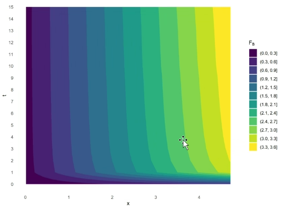

$$\mathcal F_B(t\mid x)\equiv\mathbb E\left[\frac{B_1}{Z}\mathbf 1\{\tau\leq t\}\,\middle|\,x\right]$$

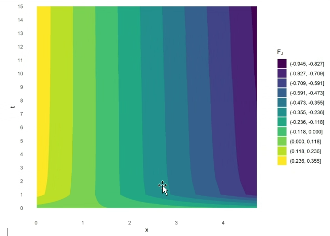

$$\mathcal F_J(t\mid x)\equiv\mathbb E\left[\frac{\Delta M}{Z}\mathbf 1\{\tau\leq t\}\,\middle|\,x\right]$$

Back